# Transmission Ratio Distortion in Extended Families

August 7, 2014 Statistical Genetics Journal Club

## About me

[figure not shown]

- http://sahirbhatnagar.com
- 2nd year PhD student (Biostatistics) with Celia
- Im interested in
  - anything applied that can contribute to society
  - big data
  - reproducible research
  - how to give a good talk
- Big believer in open source software

## Disclaimer

1. I will ask alot of questions
2. I need your help
3. Your participation is necessary for this to be useful
4. Interrupt me often

## Introduction

## What is Transmission Ratio Distortion (TRD)

- A statistical departure from the Mendelian 1:1 inheritance ratio
- Occurs when one of the two alleles from either parent is preferentially transmitted to the offspring

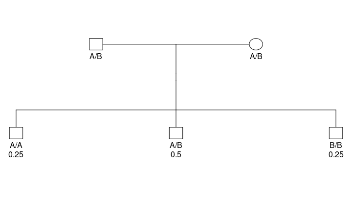

## What is Transmission Ratio Distortion (TRD)

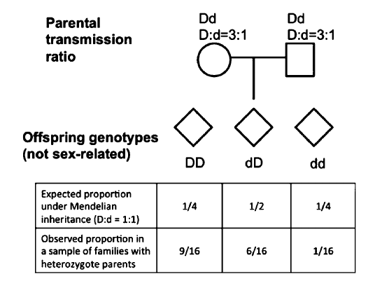

## Properties of TRD

- Can act independently of disease status
  - there are biological processes that cause TRD
  - leads to false positives in linkage/association studies
- Extent of TRD and its influence in the human genome remains incomplete
  - we didn't find any studies that looked at TRD in WGS data

## Biological Mechanisms of TRD

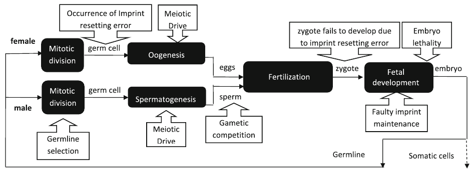

## How can we assess TRD ?

### The Transmission Disequilibrium Test (TDT)

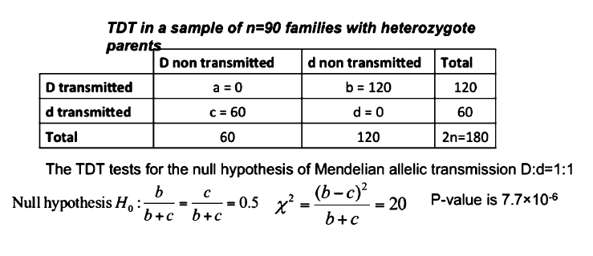

## Caveat of assesing TRD

- Can only be observed in family-based studies
  - Costs
  - Not always feasible to genotype unaffected
  - Getting in touch with family members

## A note on Test Statistics

## Test Statistics

### What we care about

[figure not shown]

## Test Statistics

### What they actually are

```
- A single measure of a sample
- It reduces the data to one value
- Need to know its sampling distribution to conduct hypothesis tests
```

\[ \textrm{Pearson} = \frac{(Observed - Expected)^2}{Expected} \sim \chi^2_{(df)} \]

\[ Z = \frac{\bar{X}-\mu}{\sigma} \sim \mathcal{N}(0,1) \]

## Test Statistics

### In general…

\[\textrm{Test Statistic} = \frac{\textrm{a measure of deviation from the "truth"}}{\textrm{a scaling factor to account for variability in your sample}} \]

- For example:
- \[H_0: \textrm{mean height}= 170 cm \rightarrow \textrm{``truth''} \]
- \[ \textrm{sample mean } \bar{X}=220cm\]
- \[ \textrm{sample sd } = 60cm \]

## What do we mean by Chi-Square Test ?

- Any statistical hypothesis test in which the sampling distribution of the test statistic is a chi-squared distribution when the null hypothesis is true
- **Chi-Square Test**
  - Pearson's goodness of fit
  - McNemar's test
  - Tukey's test of additivity
  - Likelihood ratio test

## Data

## Genetic Analysis Workshop 19 (GAW19)

- GAW19 data drawn from **T2D-GENES** Project
- Whole genome sequencing
  - 20 Mexican American Pedigrees from San Antonio
  - Enriched for type 2 diabetes
- Genotype calls cleaned of mendelian errors for 959 individuals
  - 464 directly sequenced
  - 495 imputed
  - 8.4 million markers
  - odd-numbered autosomes

## Genetic Analysis Workshop 19

### 20 Mexican American Pedigrees

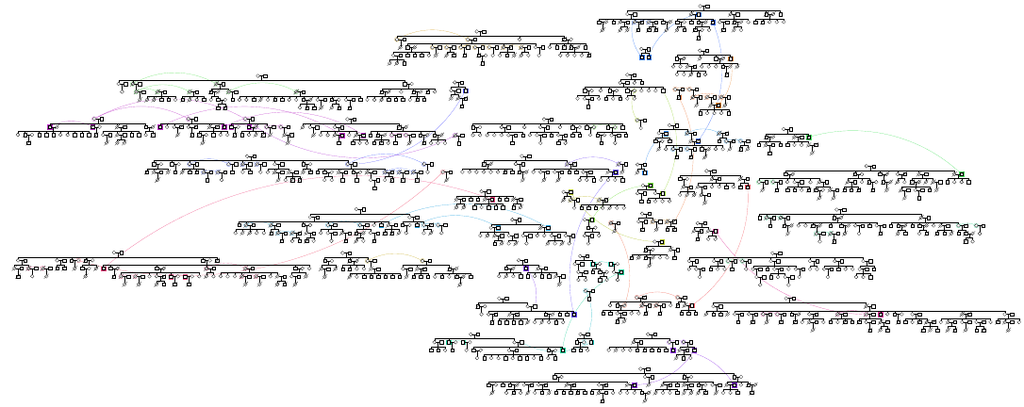

## Genetic Analysis Workshop 19

### Imputation Procedure

A novel population-based imputation approach: **Prephasing Imputation**

1. Haplotypes are estimated for each individual
2. Estimated haplotypes used directly for imputation of sequence variants
3. Imputation ignores family structure
   - to improve quality, data was cleaned for mendelian errors
4. For each missing genotype:
   - the probabilities of each possible genotype were calculated in the context of the local haplotypes
   - the resulting probabilities were then used to generate an appropriately weighted

     gene dosage variable

## Objective

## GAW19 Objective

Identify potentially distorted regions in the genome using family based association methods

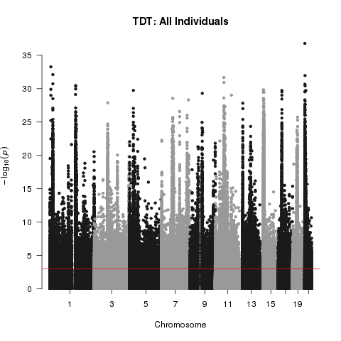

## GAW19 Objective

### My Reaction

[figure not shown]

## Methods

## Transmission Disequilibrium Test

|  | A non transmitted | B non transmitted | Total |
| --- | --- | --- | --- |
| A transmitted | a | b | a+b |
| B transmitted | c | d | c+d |
| Total | a+c | b+d | 2n |

- \[ \chi^2_{(TDT)} = \frac{(b-c)^2}{b+c} \sim \chi^2_{(1)} \]
- This is also known as a McNemar Test

## Transmission Disequilibrium Test

### Informative Trios

Need to have at least 1 heterozygous parent for trio to be informative

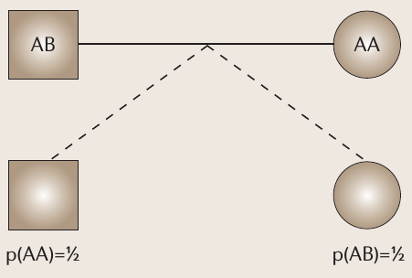

## Transmission Disequilibrium Test

### How to assess TRD

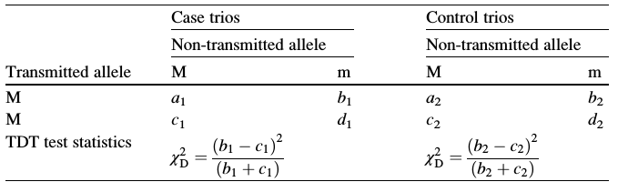

[interactive chart not shown]

## Pedigree Disequilibrium Test (PDT)

Consider a marker with two alleles \(A\) and \(B\).

**Informative families** are:

1. At least one affected child, both parents genotypes, one heterozygous parent
2. Discordant sibships (1 affected, 1 unaffected) with different genotypes, parental genotypes not required

## Pedigree Disequilibrium Test (PDT)

### Informative Trios

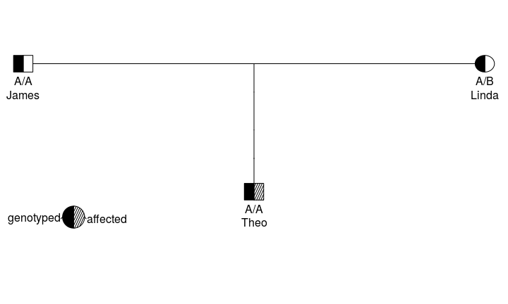

## Pedigree Disequilibrium Test (PDT)

### Informative Discordant Sibships

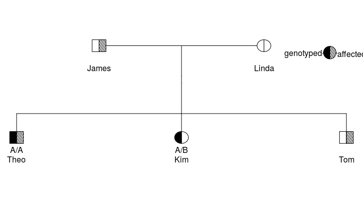

## Pedigree Disequilibrium Test (PDT)

Within an informative nuclear family define:

- \(X_T\) = (#\(A\) transmitted) - (#\(A\) not transmitted) \(\rightarrow\) \(n_T\) *trios*
- \(X_S\) = (#\(A\) affected sib) - (#\(A\) unaffected sib) \(\rightarrow\) \(n_s\) *sibships*

\[D=\frac{1}{n_T + n_S} \left( \sum X_{T} + \sum X_{S} \right) \]

For \(k=1,\ldots,N\) unrelated informative pedigrees

\[ PDT_{test} = \frac{\sum D_k}{\sqrt{\sum D_k^2 }} \sim \mathcal{N}(0,1) \]

## Family Based Association Test (FBAT)

A unified approach to family based tests of association that can handle:

1. Different genetic models
2. Sampling designs
3. Multiallelic markers
4. Quantitative traits
5. Missing parental genotype information

## Family Based Association Test (FBAT)

- The FBAT statistic is based on the **covariance** between genotype and phenotype
- What is covariance ?
- A measure of how much two random variables change together
  - \(R^2\) is normalized version of the covariance

## Family Based Association Test (FBAT)

### Test Statistic

\[ U = \sum T^* \left[ X-E(X|P) \right] \rightarrow \textrm{Covariance} \] \[ FBAT = \frac{U^2}{var(U)} \sim \chi^2_{(1)} \rightarrow \textrm{Test Statistic} \]

- \(X\): translates offspring's genotype to a numeric value e.g. count of A alleles (random)
- \(P\): genotype of offspring's parents (fixed)
- \(T\): offspring's trait (fixed)
- summation is over all offspring in the sample

## Family Based Association Test (FBAT)

### Why so flexible ?

- Of interest is the offspring's genotype
  - Missing parental genotypes are *nuisance* parameters
- Standard approach to handling *nuisance* parameters:
  - Find sufficient statistics for them
  - Condition on the sufficient statistics
  - Conditional distribution does not depend on *nuisance* parameters

## Family Based Association Test (FBAT)

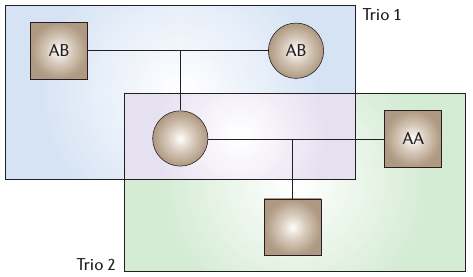

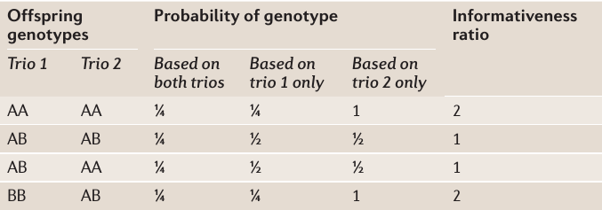

## Comparison of Methods

| attribute | TDT | PDT | FBAT |
| --- | --- | --- | --- |
| affected child | ✓ | ✓ | ✓ |
| 1 heterozygous parent | ✓ | ✓ | ✓ |
| biallelic markers | ✓ | ✓ | ✓ |
| trios | ✓ | ✓ | ✓ |
| missing parental genotypes |  | ✓ | ✓ |
| discordant sibships |  | ✓ | ✓ |
| pedigrees |  | ✓ | ✓ |
| multiallelic markers |  |  | ✓ |
| quantitative Traits |  |  | ✓ |

## Results

http://sahir.shinyapps.io/TRDtest/

## Discussion

## Observations

- Recently developed imputation algorithms giving no Mendelian errors can lead to inflated TDT results
- These false positive signals can occur for example from
  - mistyping homozygote parents as heterozygotes
  - missed calls among heterozygotes
- PDT and FBAT were not sensitive to imputation
  - more informative families being used \(\rightarrow\) more power

## Possible Reasons for Inflated TDT p-values

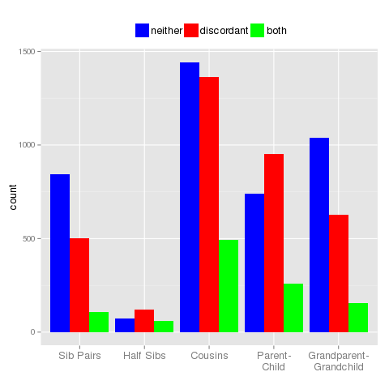

Pair counts by sequenced status. Information extracted using *PEDSTATS*

## Dosage Analysis

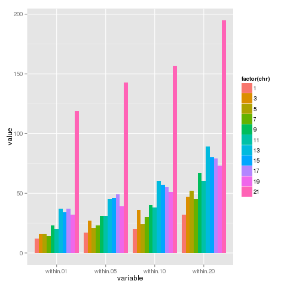

Imputed subjects within threshold at each marker by chromosome

## Unexpected HWE vs. MAF

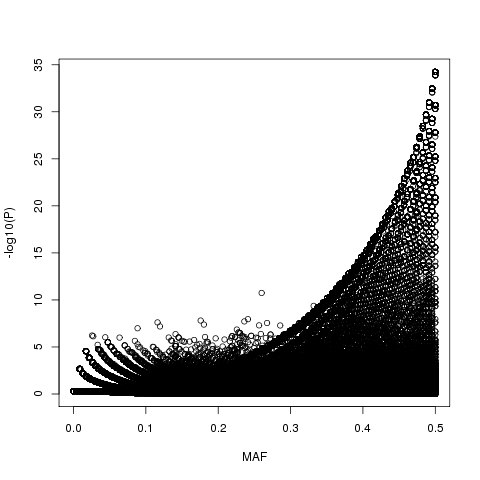

Hardy Weinberg Equilibrium p value vs. MAF for All Individuals

## Gene Set Enrichment Analysis

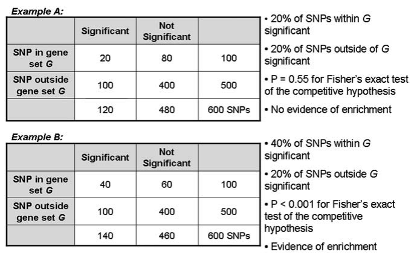

Example of Competitive Testing

## Gene Set Enrichment Analysis

[figure not shown]

## Gene Set Enrichment Analysis (GSEA)

### Using Biological Processes from Gene Ontology

- 3.3 million variants input (PDT Sequenced TRD p-value < 0.70)
- 2.2 million variants used
- 10,632 genes mapped
- 19 gene sets selected (`GO` terms related to biological mechanisms of TRD)
- 1 result (\(p<0.001\), \(FDR=0.0070\), )

[GO0045910](http://amigo.geneontology.org/amigo/term/GO:0045910): negative regulation of DNA recombination

## GSEA Results

| gene | mapped | significant | variant | -log10(p) | function |
| --- | --- | --- | --- | --- | --- |
| RAD18 | ✓ | ✓ | rs529369 | 2.35 | Postreplication repair of UV-damaged DNA |
| BLM | ✓ | ✓ | rs404623 | 2.04 | Participates in DNA replication and repair |
| LIG3 | ✓ | ✓ | rs3135966 | 2.03 | Interacts with DNA-repair protein XRCC1 |
| MSH3 | ✓ | ✓ | rs7737445 | 1.94 | Component of the post-replicative DNA mismatch repair system |
| MSH2 | ✓ |  | rs72475989 | 0.50 |  |
| MSH5 |  |  |  |  |  |
| MSH6 |  |  |  |  |  |
| ZRANB3 |  |  |  |  |  |

## Software

### ALL OPEN SOURCE !

- **Family Based Tests**: `FBAT`, `PLINK 1.9`, `PDT` command line tools
- **GSEA-SNP**: http://gsea4gwas.psych.ac.cn/
- **Plots**: `qqman`, `ggplot2`, `kinship2` packages in `R`, `cranefoot`
- **Data Cleaning**: `awk`, `bash`, `data.table` package in `R`, `GRinux`
- **Slides**: `R Markdown`, `pandoc`
- **Results App**: `Shiny` package in `R`
- **Code**: available on `GitHub`
- **Paper**: LaTeX